# Newsflow: An R package for analyzing content homogeneity and news diffusion using computational text analysis

by Kasper Welbers and Wouter van Atteveldt

## Introduction

The news diffusion process in the digital age involves many interdependent sources, ranging from news agencies and traditional newspapers to blogs and people on social media (Meraz 2011; Paterson 2005; Pew Research Center 2010). We offer the `Newsflow` package[^1] as a toolkit to analyze the homogeneity and diffusion of news content using computational text analysis. This analysis consists of two steps. First, techniques from the field of information retrieval are used to measure the similarity of news messages (e.g., addressing the same event, containing identical phrases). Second, the temporal order in which messages are published is used to analyze consistent patterns in who follows whom.

The main contribution of this package lies in the specialized application of document similarity measures for the purpose of analyzing the homogeneity and diffusion of news. News is a special type of information in the sense that it has a time dimension—it quickly loses its relevance. This package uses this by offering a function that calculates the similarity of documents using a sliding window approach, to compare only documents that occur within a given time distance. This makes it computationally feasible to compare many documents across long time periods, thus enabling comparative and longitudinal analysis. In addition, the package offers tools to organize, analyze and visualize the document similarity data.

The primary intended audience of this package is scholars and professionals in fields where the impact of news on society is a prime factor, such as journalism, political communication and public relations (Baum and Groeling 2008; Boczkowski and De Santos 2007; Ragas 2014). To what extent the content of certain sources is homogeneous or diverse has implications for central theories of media effects, such as agenda-setting and the spiral of silence (Bennett and Iyengar 2008; Blumler and Kavanagh 1999) Identifying patterns in how news travels from the initial source to the eventual audience is important for understanding who the most influential “gatekeepers” are (Shoemaker and Vos 2009). Furthermore, the document similarity data enables one to study news values (Galtung and Ruge 1965) by analyzing what elements of news predict their diffusion rate and patterns.

The package is designed to appeal to scholars and professionals without prior experience in computational text analysis. This paper covers the entire chain from processing raw data—written text with source and date information—to analyzing and visualizing the output. It points to relevant software within and outside of R for preprocessing written texts, and demonstrates how to use the core functions of this package. For more advanced users there are additional functions and parameters to support versatility. `Newsflow` is completely open-source to promote active involvement in developing and evaluating the methodology. The source code is available on Github—https://github.com/masked (repository hidden for review).

The first part of this paper discusses the data preparation. There are several choices to be made here that determine on what grounds the content of documents is compared. The second part shows how the core function for calculating document similarities is used. The third part demonstrates functions for exploring, using and visualizing the document similarity data. All the code used for this demonstration is reported, and the demo data is included in the package for easy replication.

## Preparing the data

The main input for the functions offered in this package is a document-term matrix (DTM). This is a matrix in which rows represent documents, columns represent terms, and cells indicate how often each term occurred in each document. The DTM has to be in the `document term matrix` class of the `tm` package—a popular package for text mining in R. The `tm` package contains functions to create this data based on raw text. We also recommend the RTextTools package, which combines `tm` functions in a single `create_matrix` function.

Using a DTM is a so-called *bag of words* approach, since we ignore the order of words. Research points out that ``A simple list of words, which we call unigrams, is often sufficient to convey the general meaning of a text’’ (Grimmer and Stewart 2013: 6). For many applications in text analysis this bag of words representation gives better results when certain additional steps for *preprocessing* the data are performed. This also allows us to steer on what elements documents are compared.

- First of all, it is advisable to make all terms lowercase, and reduce terms to their root using stemming or lemmatizing[^2]. Thus, “Hope”, “hoped”, “hoping”, etc. all become “hope”. This is because we are interested in the meaning of these terms, and not the specific form in which they are used.
- Second, one should filter out irrelevant words. Very common words, stopwords and boilerplate words contain little or no information about news items. Very rare terms, while ignored in many computational text analysis approaches, are particularly informative for our current purpose, and should be kept.
- Third, It is also possible to specifically select or filter out only certain types of words by using part-of-speech tagging[^3]. For instance, to compare whether documents address the same event it makes sense to focus on nouns and proper names.
- Finally, an alternative approach is to combine words into N-grams (i.e. sets of N consecutive words). This way the comparison of documents focuses more on similarity in specific segments of text, which is useful if the goal is to trace whether news outlets literally copy each other (in which case most other pre-processing steps can be skipped).

All mentioned preprocessing steps except for lemmatizing and part-of-speech tagging are available in the `tm` package and in the `create_matrix` function of the `RTextTools` package. To use lemmatization or part-of-speech tagging there are several free to use grammar parsers, such as *CoreNLP* for English (Manning et al. 2014) and *Frog* for Dutch (Van den Bosch et al. 2007).

For this paper, data is used that has been preprocessed with the Dutch grammar parser Frog. The data is based on a recent study on the influence of a Dutch news agency on the print and online editions of Dutch newspapers in political news coverage (Author citation, forthcoming). The terms have been lemmatized, and only the nouns and proper names of the headline and first five sentences (that generally contain the essential who, what and where of news) are used. By focusing on these elements, the analysis in this study focused on whether documents address the same events. This data is also made available in the package as demo data[^4].

Externally preprocessed data can be imported into R as a data.frame with three columns, in which each row indicates the document, term, and a frequency for how often the term occurred in this document—similar to a coordinate list (COO) representation of a sparse matrix. To create a DTM based on this data, we can use the base function `xtabs` to create a sparse matrix, and the `as.DocumentTermMatrix` function from the `tm` package to transform this to a DTM.

```r
data(terms)
m = xtabs(freq ~ document_id + term, terms, sparse = T)
dtm = as.DocumentTermMatrix(m, weighting = weightTf)
```

In addition to the DTM, we need meta information about (at least) the publication time and source of each document. This should be structured as a data frame that contains a column labeled `document_id`, that should match with the rownames (i.e. documents) of the DTM. The date values should be in the `Date` or `POSIXct` class. The following code loads the meta data and matches the rows to the DTM.

```r
data(meta)

match_indices = match(rownames(dtm), meta$document_id)
meta = meta[match_indices,]
head(meta)
```

|  | document_id | date | source | sourcetype |
| --- | --- | --- | --- | --- |
| 128269 | 35573532 | 2013-06-01 06:00:00 | Newspaper 2 print | Print newspapers |
| 128271 | 35573536 | 2013-06-01 06:00:00 | Newspaper 2 print | Print newspapers |
| 128273 | 35573539 | 2013-06-01 06:00:00 | Newspaper 2 print | Print newspapers |
| 128706 | 35620308 | 2013-06-01 19:33:00 | Newspaper 1 online | Online newspapers |
| 128715 | 35620317 | 2013-06-01 16:37:00 | Newspaper 1 online | Online newspapers |
| 128718 | 35620320 | 2013-06-01 16:23:00 | Newspaper 1 online | Online newspapers |

Given the DTM and meta information, we can calculate statistics for the occurrence of words, based on which we can filter out words that are not relevant for our analysis. Since we are analyzing news diffusion, a particularly interesting characteristic of words is the distribution of their use over time. To focus the comparison of documents on words that indicate new events, we can filter out words that are evenly used over time. To calculate this, we offer the `term.day.dist` function.

```r
tdd = term.day.dist(dtm, meta)
head(tdd)
```

|  | term | freq | doc.freq | days.n | days.pct | days.entropy | days.entropy.norm |
| --- | --- | --- | --- | --- | --- | --- | --- |
| EVE 1 | EVE 1 | 61 | 45 | 9 | 0.3000000 | 6.525910 | 0.2175303 |
| EVE 10 | EVE 10 | 2 | 2 | 2 | 0.0666667 | 2.000000 | 0.0666667 |
| EVE 11 | EVE 11 | 4 | 4 | 2 | 0.0666667 | 1.754765 | 0.0584922 |
| EVE 12 | EVE 12 | 1 | 1 | 1 | 0.0333333 | 1.000000 | 0.0333333 |
| EVE 13 | EVE 13 | 3 | 3 | 1 | 0.0333333 | 1.000000 | 0.0333333 |
| EVE 14 | EVE 14 | 3 | 3 | 1 | 0.0333333 | 1.000000 | 0.0333333 |

The most interesting output is the `days.entropy` score, which is the entropy of the distribution of words over days. This tells us whether the occurrence of a word over time is evenly distributed (high entropy) or concentrated (low entropy).[^5] The maximum value for entropy is the total number of days (in case of a uniform distribution). The `days.entropy.norm` score normalizes the entropy by dividing by the number of days. By selecting the terms with low entropy scores, the DTM can be filtered by using the selected terms as column values.

```r
select_terms = tdd$term[tdd$days.entropy.norm <= 0.3]
dtm = dtm[,select_terms]
```

## Calculating document similarities

To efficiently compare many documents, a vector space model (VSM) approach is used (Salton, Wong, and Yang 1975; Salton and Harman 2003).[^6] An established and often used VSM approach is to first weight the document vectors using the tf.idf (term frequency - inverse document frequency) weighting scheme, and then calculate the similarity of the document vectors based on the cosine distance of their angles. Although this package allows other weighting schemes and similarity measures to be used, this paper uses (and currently recommends) the tf.idf and cosine similarity approach.

The `tm` package offers several ways to weight a DTM in the `DocumentTermMatrix` class. To weight on tf.idf, the `weightTfIDF` function can be used.

```r
dtm = weightTfIdf(dtm)
```

Given a (weighted) DTM and corresponding document meta data, the document similarities over time can be calculated with the `documents.window.compare` function. This function has two main data inputs: the DTM and a data.frame with meta information. The meta data.frame should have a column containing document id’s that match the rownames of the DTM (i.e. documents) and should have a column indicating the publication time. By default these columns should be labeled ‘document_id’ and ‘date’, but this can be set using the `id.var` and `date.var` parameters. Any other columns will automatically be included as document meta information in the output.

Furthermore, three parameters are of particular importance. The `hour.window` parameter determines the time window in hours within which each document is compared to other documents. The argument is a vector of length 2, in which the first and second value determine the left and right side of the window, respectively. For example, c(-36,0) will compare each document to all documents within the previous 36 hours. The `measure` parameter, which determines what measure for similarity is used, defaults to *cosine similarity*. This is a commonly used measure, which indicates similarity as a score between 0 (no similarity) and 1 (identical)[^7].  
The `min.similarity` parameter is used to ignore all documents pairs below a certain similarity score. This reduces the size of the output, which can be necessary with larger datasets, given that the number of document pairs increases exponentially as the number of documents increases.

```r
g = documents.window.compare(dtm, meta,
                             hour.window = c(-36,0),
                             min.similarity = 0.4)
```

The output `g` is a network, or graph, in the format of the `igraph` package. The vertices (or nodes) of this network represent documents, and the date and source of each document are stored as vertex attributes. The edges (or ties) represent the similarity of documents, and the similarity score and time difference are stored as edge attributes. An advantage of using a network format is that it combines this data in an efficient way, without copying the vertex meta information for each edge. This network forms the basis for all the analysis function offered in this package[^8]. Alternatively, both elements of the data can easily be viewed or extracted with the `get.data.frame` function of the `igraph` package.

```r
v = get.data.frame(g, 'vertices')
e = get.data.frame(g, 'edges')

head(v,3)
```

|  | name | date | source | sourcetype |
| --- | --- | --- | --- | --- |
| 97359230 | 97359230 | 2013-06-01 10:52:00 | Newsagency | Newsagencies |
| 35621313 | 35621313 | 2013-06-01 11:59:00 | Newspaper 1 online | Online newspapers |
| 36156099 | 36156099 | 2013-06-06 04:41:00 | Newspaper 2 online | Online newspapers |

```r
head(e,3)
```

| from | to | weight | hourdiff |
| --- | --- | --- | --- |
| 35621313 | 97359230 | 1 | -1.117 |
| 36122088 | 36156099 | 1 | -2.267 |
| 36122088 | 97362434 | 1 | -4.900 |

The `weight` attribute of the edges represents the similarity score. The `hourdiff` attribute represents the time difference in hours between two documents, where a negative score indicates that the `to` article was published before the `from` article. Note that this corresponds with the `hour.window` parameter of the `documents.window.compare` function. A histogram can provide a good first indication of this data.

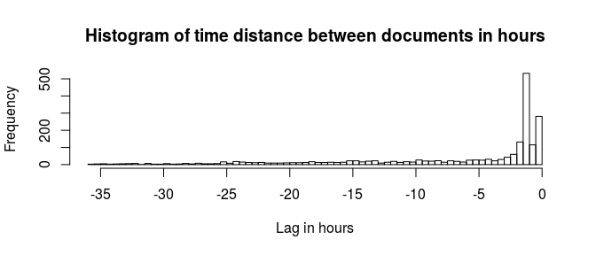

```r
hist(E(g)$hourdiff, main='Histogram of time distance between documents in hours',
     xlab = 'Lag in hours', breaks = 100)
```

In the histogram we see that most document pairs with a similarity score above the threshold are about an hour apart (-1 on the x-axis). This is mainly because the online newspapers often follow the news agency within a very short amount of time. As time distance increases, the number of document pairs decreases, which makes sense because news gets old fast, so news diffusion should occur within a limited time after publication.

The `source.window.settings` function creates a data.frame that contains for each source the minimum and maximum amount of lag. Alternatively, if the meta information also contained another relevant grouping attribute such as source type, this can also be used, as we’ll demonstrate.  
In the following example the minimium and maximum lag is set to 0.1 and 36 hours, respectively. For print newspapers, the minimum lag is then manually set to 6 hours to account for their publication delay.[^9]

```r
source.window = source.window.settings(g, max.window.left = -36, max.window.right = -0.1,
                                       meta.attribute='sourcetype')
source.window$window.right[source.window$sourcetype == 'Print newspapers'] = -6
source.window
```

| sourcetype | window.left | window.right |
| --- | --- | --- |
| Newsagencies | -36 | -0.1 |
| Online newspapers | -36 | -0.1 |
| Print newspapers | -36 | -6.0 |

```r
g = filter.window(g, source.window)
show.window(g)
```

| source | window.left | window.right |
| --- | --- | --- |
| Newsagency | -35.417 | -0.150 |
| Newspaper 1 online | -35.833 | -0.100 |
| Newspaper 1 print | -36.000 | -7.017 |
| Newspaper 2 online | -35.950 | -0.117 |
| Newspaper 2 print | -35.083 | -7.350 |

Note that currently we are only comparing documents to prior documents. This way, we focus the analysis on whether each document is potentially influenced by certain other documents. By changing the window setting, it is also possible to compare each document to both prior and future documents, to focus on content homogeneity. Or to compare only to future documents, to focus the analysis on whether each document potentially influenced other documents.

## Aggregating and visualizing the document similarity network

Before we aggregate the network, it can be informative to look at the individual components. That is, disconnected parts of the network consisting of one or more documents that are only similar to each other. With the current data, these components tend to reflect documents that address the same or related events. To inspect components, we can use the `plot.document.network` function. This function draws a network where nodes (i.e. documents) are positioned based on their date and time (x-axis) and source (y-axis). If an integer is given as an argument for the subcomp parameter, then this specific subcomponent is visualized and returned. Without the subcomp parameter the entire network will be plotted, which is only useful with smaller graphs. If a DTM is also provided, the visualization will include a word cloud with the common words of these documents. Also, the source attribute can be changed to other interesting meta attributes such as source type.

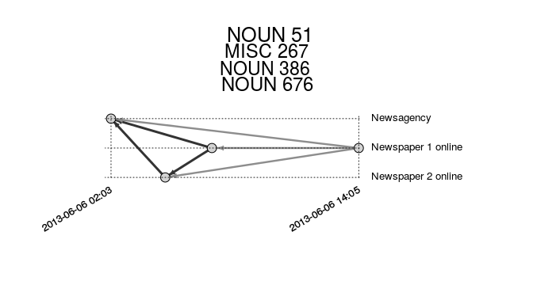

```r
## Visualize and extract individual components of the network
sg2 = plot.document.network(g, subcomp = 2, dtm=dtm)
```

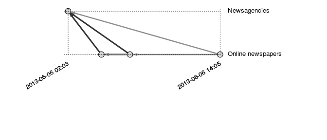

```r
sg2_sourcetype = plot.document.network(g, subcomp = 2, source.attribute = 'sourcetype')
```

These visualizations illustrate how we can analyze homogeneity and news diffusion patterns. For each source we can count what proportion of its publications is similar to earlier publications by specific other sources. We can also analyze the average time between publications.

The `aggregate.network` function performs these calculations by aggregating the edges in the network based on the vertex attributes (i.e. the meta information). The first argument is the `igraph` network. The arguments for `by.from` and `by.to` are character vectors to indicate one or more vertex attributes. This gives flexible control over the data, for instance to analyze source to source influence, or source to sourcetype, or to analyze per month (after adding month as a vertex attribute). By default, the function returns the number of edges, as well as the number of nodes that is connected for both the `from` and `to` group. In addition, an `edge.attribute` can be given and a function to aggregate this attribute. For this example we use this to analyze the median of the `hourdiff` attribute.

```r
source_to_source = aggregate.network(g, by.from = 'source', by.to='source',
                                     edge.attribute='hourdiff', agg.FUN=median)
s.type_to_s.type = aggregate.network(g, by.from = 'sourcetype', by.to='sourcetype',
                                     edge.attribute='hourdiff', agg.FUN=median)

## Table printed in two parts due to width
head(s.type_to_s.type[,1:7])
```

| from.sourcetype | to.sourcetype | edges | agg.hourdiff | from.matched | from.N | from.prop |
| --- | --- | --- | --- | --- | --- | --- |
| Newsagencies | Newsagencies | 124 | -8.0835 | 95 | 597 | 0.1591290 |
| Online newspapers | Newsagencies | 830 | -1.3000 | 714 | 879 | 0.8122867 |
| Print newspapers | Newsagencies | 98 | -16.0915 | 79 | 278 | 0.2841727 |
| Newsagencies | Online newspapers | 180 | -5.6250 | 114 | 597 | 0.1909548 |
| Print newspapers | Online newspapers | 155 | -15.0500 | 86 | 278 | 0.3093525 |
| Online newspapers | Online newspapers | 379 | -1.8330 | 291 | 879 | 0.3310580 |

```r
head(s.type_to_s.type[,c(1:4, 8:10)])
```

| from.sourcetype | to.sourcetype | edges | agg.hourdiff | to.matched | to.N | to.prop |
| --- | --- | --- | --- | --- | --- | --- |
| Newsagencies | Newsagencies | 124 | -8.0835 | 112 | 597 | 0.1876047 |
| Online newspapers | Newsagencies | 830 | -1.3000 | 543 | 597 | 0.9095477 |
| Print newspapers | Newsagencies | 98 | -16.0915 | 89 | 597 | 0.1490787 |
| Newsagencies | Online newspapers | 180 | -5.6250 | 158 | 879 | 0.1797497 |
| Print newspapers | Online newspapers | 155 | -15.0500 | 143 | 879 | 0.1626849 |
| Online newspapers | Online newspapers | 379 | -1.8330 | 334 | 879 | 0.3799772 |

The default output is a data.frame where the edges of each unique combination of the `from` and `to` groups are aggregated. For example, we see that online newspaper documents have 830 edges to news agency documents that were published within the previous 36 hours. The median of the difference in hours of these documents is -1.3 (1 hour and 18 minutes). The `from.matched` column indicates the number of unique online newspaper documents that matched with a news agency document[^10]. The `from.N` column indicates the total number of online newspaper documents, and `from.prop` is the proportion of online newspaper documents that matched with a news agency document. Substantially, the `from.prop` score thus indicates that 81.23% of political news in online newspapers is similar or identical to recent news agency news. This indicates that online newspapers rely heavily on the news agency as a source of political news.

The `matched`, `N` and `prop` scores are also reported for the `to` group. This gives an interesting inversed perspective on the relation between online newspapers and news agencies. Based on the `to.prop` score, we see that 90.95% of political news published by the news agency is similar or identical to future online newspaper news. If a news agency publishes a political news item, it is very likely that this item will soon after be published by at least one online newspaper. Thus note that `from.prop` and `to.prop` are related but different scores, and can be used complementary or to answer different research questions.

In the current aggregation we looked at all edges, but depending on the purpose of the analysis it can be relevant to filter first. For illustration, look again at the first visualization of the subcomponent. Here the publications of `Newspaper 1 online` match previous publications of both the news agency and the other online newspaper. If we are specifically interested in who the original source of the news is, then it makes sense to only count the edges to the news agency. This package therefore offers the `only.first.match` function, which will transform the network so that each document can only have 1 edge: to the earliest dated document it matches within the specified time window.

To demonstrate how this affects the results, we compare the previous aggregation with an aggregation of the transformed network. For this, we also demonstrate the `return.network` parameter of the `aggregate.network` function, which returns the output as an `igraph` network. For the edge weight we use the `from.prop` score. We plot both networks, using a threshold of 0.05 for the proportion score for the sake of parsimony.

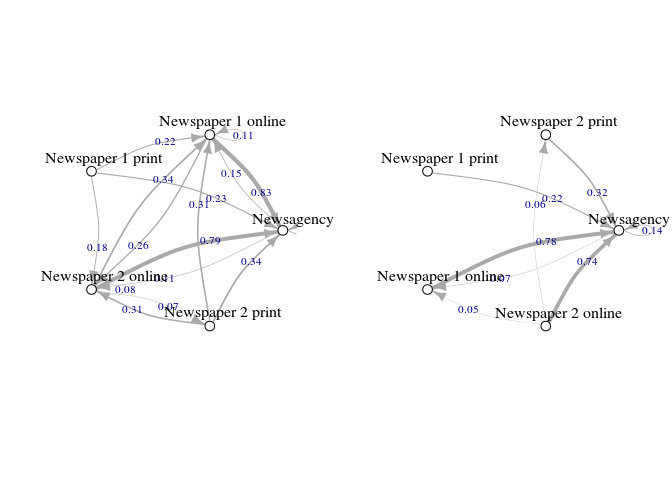

```r
g2 = only.first.match(g)
permed.g1 = aggregate.network(g, by.from='source', by.to='source',
                              return.network = T, network.edge.weight = 'from.prop')
permed.g2 = aggregate.network(g2, by.from='source', by.to='source',
                              return.network = T, network.edge.weight = 'from.prop')

permed.g1 = delete.edges(permed.g1, which(E(permed.g1)$weight < 0.05))
permed.g2 = delete.edges(permed.g2, which(E(permed.g2)$weight < 0.05))

par(mfrow = c(1,2))
plot(permed.g1, layout=layout.circle, vertex.label.dist=0.6, edge.label.cex = 0.7)
plot(permed.g2, layout=layout.circle, vertex.label.dist=0.6, edge.label.cex = 0.7)
```

The first network is much more dense compared to the second. In particular, we see stronger edges between the print and online editions of the newspapers. In the second network almost only the ties to the news agency remain. This implies that many of the edges between newspapers result from cases where both newspapers adopt the same news agency articles.

Note that the second network is not better per se. Consider, for instance, that a blog might most of its information from an online newspaper, in which case the news agency is often still the initial source, but the newspaper is a crucial gatekeeper. Depending on the purpose of the analysis, either approach can thus be more suitable.

Finally, a useful alternative way to organize the data is as a data.frame that shows for each document whether and if so how strongly it matches with other sources. For this we can use the `topSimilarities` function. The output is a data.frame where the rows represent unique documents. For each document the score for the strongest match to each other source is given (or zero if no match is found). In this format the data can easily be matched to data on content characteristics of individual documents.

```r
topsim = topSimilarities(g, break.by='sourcetype')
head(topsim,4)
```

| id | date | Newsagencies | Online newspapers | Print newspapers |
| --- | --- | --- | --- | --- |
| 97359230 | 2013-06-01 10:52:00 | 0 | 0 | 0 |
| 35621313 | 2013-06-01 11:59:00 | 1 | 0 | 0 |
| 36156099 | 2013-06-06 04:41:00 | 1 | 0 | 0 |
| 97362434 | 2013-06-06 02:03:00 | 0 | 0 | 0 |

## Conclusion and future improvements

We have demonstrated how the *newsflow* package can be used to perform a many-to-many comparison of documents. The primary focus and most important feature of this package is the `documents.window.compare` function. This function compares all documents that occur within a given time distance, which makes it computationally feasible for longitudinal data. Using this data, we can analyze to what extent different sources publish the same content and whether there are consistent patterns in who follows whom. The secondary focus of this package is to provide functions to conduct this analysis, and to provide a platform for scholars to share additional or alternative approaches.

The data input required for this analysis consists solely of textual documents and their corresponding publication date and source. If the texts are imported as natural language, the `tm` package or `RTextTools` package can be used to preprocess them and to create a DTM. If the texts are imported as preprocessed tokens, the `create.dtm` function can be used to create a DTM. Since no human coding is required, the package enables large scale comparative and longitudinal studies. Although the demonstration in this paper used a moderate sized dataset, the functions can handle much larger data.[^11]

The goal is to continue developing this package as a specialized toolkit for analyzing the homogeneity and diffusion of news content. First of all, additional approaches for measuring whether documents are related will be added. Currently only a vector space model approach for calculating document similarity is implemented[^12]. For future versions alternative approaches such as language modeling will also be explored. In particular, we want to add alternative measures to express the relation of documents over time in terms of probability and information gain. This would also allow us to define a more formal way to determine whether or not a relation exists, other than using a similarity threshold. Secondly, new methods for analyzing and visualizing the network data will be explored. In particular, methods will be implemented for analyzing patterns beyond dyadic ties between news outlets, building on techniques from the field of network analysis.

Ultimately, the goal is to extract communication networks from content data for many sources over time. This package contributes to this goal by facilitating different approaches for creating and aggregating the document network.

References

Baum, Matthew A, and Tim Groeling. 2008. “New Media and the Polarization of American Political Discourse.” *Political Communication* 25 (4). Taylor & Francis: 345–65.

Bennett, W Lance, and Shanto Iyengar. 2008. “A New Era of Minimal Effects? The Changing Foundations of Political Communication.” *Journal of Communication* 58 (4). Wiley Online Library: 707–31.

Blumler, Jay G, and Dennis Kavanagh. 1999. “The Third Age of Political Communication: Influences and Features.” *Political Communication* 16 (3). Taylor & Francis: 209–30.

Boczkowski, Pablo J, and Martin De Santos. 2007. “When More Media Equals Less News: Patterns of Content Homogenization in Argentina’s Leading Print and Online Newspapers.” *Political Communication* 24 (2). Taylor & Francis: 167–80.

Galtung, Johan, and Mari Holmboe Ruge. 1965. “The Structure of Foreign News the Presentation of the Congo, Cuba and Cyprus Crises in Four Norwegian Newspapers.” *Journal of Peace Research* 2 (1). Sage Publications: 64–90.

Grimmer, Justin, and Brandon M Stewart. 2013. “Text as Data: The Promise and Pitfalls of Automatic Content Analysis Methods for Political Texts.” *Political Analysis* 21 (3). SPM-PMSAPSA: 267–97.

Manning, Christopher D., Mihai Surdeanu, John Bauer, Jenny Finkel, Steven J. Bethard, and David McClosky. 2014. “The Stanford CoreNLP Natural Language Processing Toolkit.” In *Proceedings of 52nd Annual Meeting of the Association for Computational Linguistics: System Demonstrations*, 55–60. http://www.aclweb.org/anthology/P/P14/P14-5010.

Meraz, Sharon. 2011. “Using Time Series Analysis to Measure Intermedia Agenda-Setting Influence in Traditional Media and Political Blog Networks.” *Journalism & Mass Communication Quarterly* 88 (1). SAGE Publications: 176–94.

Paterson, Chris. 2005. “News Agency Dominance in International News on the Internet.” *Converging Media, Diverging Politics. Lanham, MD: Lexington Books*, 145–63.

Pew Research Center. 2010. “New Media Old Media: How Blogs and Social Media Agendas Relate.” Available at: http://www.journalism.org/node/20621.

Ragas, Matthew W. 2014. “Intermedia Agenda Setting in Business News Coverage.” *Communication and Language Analysis in the Public Sphere*. IGI Global, 335.

Salton, Gerard, and Donna Harman. 2003. *Information Retrieval*. John Wiley; Sons Ltd.

Salton, Gerard, Anita Wong, and Chung-Shu Yang. 1975. “A Vector Space Model for Automatic Indexing.” *Communications of the ACM* 18 (11). ACM: 613–20.

Shoemaker, Pamela J, and Timothy Vos. 2009. *Gatekeeping Theory*. Routledge.

Van den Bosch, A, G.J. Busser, W. Daelemans, and S. Canisius. 2007. “An Efficient Memory-Based Morphosyntactic Tagger and Parser for Dutch.” *Selected Papers of the 17th Computational Linguistics in the Netherlands Meeting*. Leuven.

[^1]: Note to reviewer. The target journal for this manuscript is the R Journal, which specifically focuses on papers that introduce new packages for the R statistical software. As such, convention is that it is not explained what R is. For reference, R is an open-source statistical software package (https://www.r-project.org/).
[^2]: Stemming and lemmatization are both techniques for reducing words to their root, or stem. This is used to group different forms of the same word together. Without going into specifics, the difference is that lemmatization is a much more computationally demanding approach, but generally gives better results. Especially for richly inflicted languages such as German or Dutch it is highly advised to use lemmatization instead of stemming.
[^3]: Part-of-speech tagging is a technique that identifies types of words, such as verbs, nouns and adjectives.
[^4]: The newspapers have been made anonymous, and words have been transformed to reveal only the type of word (e.g, noun, person, organization, location).
[^5]: Note that this is also a good automatic approach for filtering out stopwords, boilerplate words, and word forms such as articles and common verbs.
[^6]: In future versions alternative document similarity measures will be added.
[^7]: If the DTM contains negative values, the cosine similarity score can range from -1 to 1.
[^8]: If data about document similarities is imported, then the `document.network` function can be used to create this network. This way the analysis functions of this package can still be used.
[^9]: Note that the `source.window.settings` function also has a `direct.edit` parameter, which invokes a text editor to make manual adjustments.
[^10]: Note that the `edges` score can be higher (but not lower) than the `from.matched` score, since one document can match with multiple other documents.
[^11]: A test showed that on a laptop with 8Gb RAM and a 1.80GHz processor (no multi-threading used) the analysis performed well with a DTM containing 315.000 documents and 120.000 unique terms. This data covered 1 year in 14 sources, and a window of 3 days and threshold of 0.4 was used.
[^12]: This is because we currently rely on matrix multiplication as a computationally efficient way to calculate inner-product based similarity scores, such as cosine similarity.